# BRIEF Self-Report Scoring

Leandro Ledesma

2024-02-09

### Universal block code settings

```r
knitr::opts_chunk$set(echo = TRUE)
knitr::opts_chunk$set(message = FALSE)
knitr::opts_chunk$set(comment = NULL)
```

### Load in the data manipulation packages first

```r
library(tidyverse)
library(ggplot2)
library(ggpubr)
library(readxl)
library(kableExtra)
library(fuzzyjoin)
```

### Load in the data

```r
# Set working directory
setwd("~/ONR/Qualtrics")

# Load in the data
Qualtrics <- read.csv("ONR Questionnaires_February 9, 2024_10.47.csv")
```

### Investigate the data

```r
# The data dimensions
dim(Qualtrics)
```

```
[1]  228 1163
```

### Extract BRIEF Questions

Q1-Q16 are items from the BRIEF self-report.

We are now going to do some data cleaning to extract the items for inhibition and working memory. Most of the data is missing because this measure was introduced much later into the study. Thus NA’s will be removed from the plots below that show the frequency of responses for each item for both Inhibition and Working Memory.

```r
# Extract all BRIEF Inhibition Questions and save it into an object
Inhibition <- Qualtrics[,c("ID", paste("Q",1:8,sep=""))]

# Extract all BRIEF Working Memory Questions and save it into an object
Working.Memory <- Qualtrics[,c("ID", paste("Q",9:16,sep=""))]

# Data cleaning, remove the first 17 rows- they do not provide meaningful information
# Data row 18 is the row of subject 001
Inhibition <- Inhibition[18:nrow(Inhibition),]
Working.Memory <- Working.Memory[18:nrow(Working.Memory),]
```

### Calculate the percentage of NA’s in the data

```r
# Convert any NA's in the dataframes into NA character
Inhibition.NA <- Inhibition %>%
  select(-ID) %>%
  lapply(function(x) ifelse(x == "", "NA", x)) %>%
  do.call(cbind, .) %>%
  data.frame()

Working.Memory.NA <- Working.Memory %>%
  select(-ID) %>%
  lapply(function(x) ifelse(x == "", "NA", x)) %>%
  do.call(cbind, .) %>%
  data.frame()

# Obtain the frequency of response for each item in both data frames
Inhibition.counts <- Inhibition.NA %>%
  lapply(.,function(x) table(x)) %>%
  do.call(cbind,.) %>%
  data.frame()

Working.Memory.counts <- Working.Memory.NA %>%
  lapply(.,function(x) table(x)) %>%
  do.call(cbind,.) %>%
  data.frame()

# Add the row names as a variable
Inhibition.counts$Responses <- row.names(Inhibition.counts)
Working.Memory.counts$Responses <- row.names(Working.Memory.counts)

# Print the percentage of NA's present for both datasets
Inhibition.counts %>%
  t() %>%
  data.frame() %>%
  mutate(X1 = as.numeric(X1),
         X2 = as.numeric(X2),
         X3 = as.numeric(X3),
         NA. = as.numeric(NA.),
         `NA %` = NA./(X1 + X2 + X3 + NA.)*100) %>%
  round(3) %>%
  mutate(`NA %` = paste(`NA %`,"%")) %>%
  filter(complete.cases(.)) %>%
  select(`NA %`) %>%
  kbl() %>%
  kable_paper(full_width = F)
```

|  | NA % |
| --- | --- |
| Q1 | 60.664 % |
| Q2 | 60.664 % |
| Q3 | 61.137 % |
| Q4 | 60.664 % |
| Q5 | 60.664 % |
| Q6 | 60.664 % |
| Q7 | 60.664 % |
| Q8 | 60.664 % |

```r
Working.Memory.counts %>%
  t() %>%
  data.frame() %>%
  mutate(X1 = as.numeric(X1),
         X2 = as.numeric(X2),
         X3 = as.numeric(X3),
         NA. = as.numeric(NA.),
         `NA %` = NA./(X1 + X2 + X3 + NA.)*100) %>%
  round(3) %>%
  mutate(`NA %` = paste(`NA %`,"%")) %>%
  filter(complete.cases(.)) %>%
  select(`NA %`) %>%
  kbl() %>%
  kable_paper(full_width = F)
```

|  | NA % |
| --- | --- |
| Q9 | 60.664 % |
| Q10 | 60.664 % |
| Q11 | 60.664 % |
| Q12 | 60.664 % |
| Q13 | 60.664 % |
| Q14 | 60.664 % |
| Q15 | 60.664 % |
| Q16 | 60.664 % |

### Plot the proprotion of responses for each item

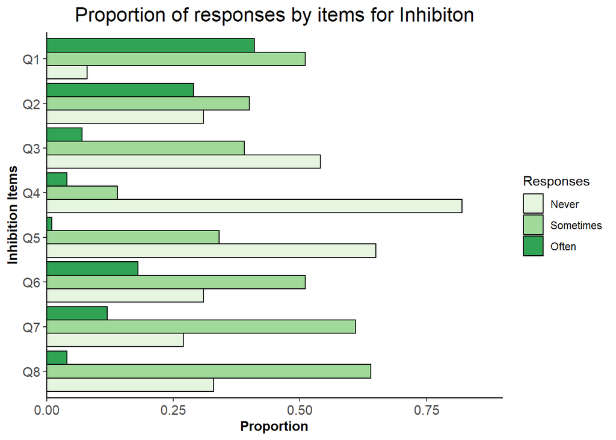

```r
# Convert data frames into long format
Inhibition.prop <- Inhibition.counts %>%
  filter(Responses != "NA") %>%
  pivot_longer(-Responses) %>%
  group_by(name) %>%
  mutate(Prop = round(value/sum(value),2),
         name = factor(name, levels =c(paste("Q",8:1,sep=""))),
         Responses = factor(Responses,
                          levels = c(1,2,3),
                          labels = c("Never","Sometimes","Often")))

# Graph
Inhibition.prop %>%
  ggplot(aes(x = name, y = Prop, fill = Responses)) +
  geom_bar(stat = "identity", position = "dodge", color = "black") +
  scale_y_continuous(expand = c(0,0), limits = c(0,.9)) +
  coord_flip() +
  theme_classic() +
  scale_fill_brewer(palette = "Greens") +
  labs(title = "Proportion of responses by items for Inhibiton",
       x = "Inhibition Items",
       y = "Proportion") +
  theme(plot.title = element_text(size = 16,
                                 hjust = 0.5),
        axis.title = element_text(size = 11, face = "bold"),
        axis.text = element_text(size = 11))
```

Q1: I tap my fingers or bounce my legs (Question 5)

Q2: I have trouble sitting still (Question 16)

Q3: I have problems waiting my turn (Question 29)

Q4: I make inappropriate sexual comments (Question 36)

Q5: I make decisions that get me into trouble (legally, financially, socially) (Question 43)

Q6: People say I am easily distracted (Question 55)

Q7: I rush through things (Question 58)

Q8: I am impulsive (Question 73)

From the graph above, we can see that with the exception of Q1 & Q2, responses tend to be mostly ‘sometimes’ or ‘never’ to the impulsive related items.

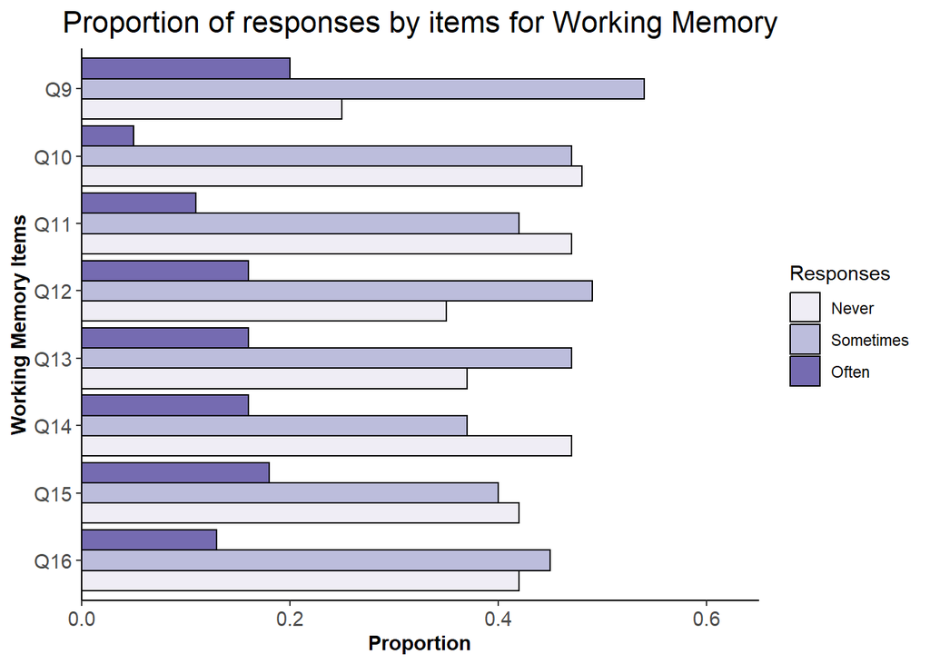

```r
# Convert data frames into long format
Working.Memory.prop <- Working.Memory.counts %>%
  filter(Responses != "NA") %>%
  pivot_longer(-Responses) %>%
  group_by(name) %>%
  mutate(Prop = round(value/sum(value),2),
         name = factor(name, levels =c(paste("Q",16:9,sep=""))),
         Responses = factor(Responses,
                          levels = c(1,2,3),
                          labels = c("Never","Sometimes","Often")))

# Graph
Working.Memory.prop %>%
  ggplot(aes(x = name, y = Prop, fill = Responses)) +
  geom_bar(stat = "identity", position = "dodge", color = "black") +
  scale_y_continuous(expand = c(0,0), limits = c(0,.65)) +
  coord_flip() +
  theme_classic() +
  scale_fill_brewer(palette = "Purples") +
  labs(title = "Proportion of responses by items for Working Memory",
       x = "Working Memory Items",
       y = "Proportion") +
  theme(plot.title = element_text(size = 16,
                                 hjust = 0.5),
        axis.title = element_text(size = 11, face = "bold"),
        axis.text = element_text(size = 11))
```

Q9: I have trouble concentrating on tasks (such as chores, reading, or work) (Question 4)

Q10: I have troubles with jobs or tasks that have more than one step (Question 11)

Q11: I forget what I am doing in the middle of things (Question 17)

Q12: I have trouble staying on the same topic when talking (Question 26)

Q13: I have a short attention span (Question 35)

Q14: I forget instructions easily (Question 46)

Q15: I have trouble remembering things (Question 56)

Q16: I have trouble doing more than one thing at a time (Question 68)

### Missing data handling

After following this procedure we are left with 80 participants for both Inhibition and Working Memory. In addition, we dropped ID’s 125 and n126 since there were two copies of 125 and ID 127 was not present. Thus this needs to be resolved in the original Qualtrics CSV before they can be further included.

```r
# Remove the following 'IDs' since we cannot tell who they actually belong to
Inhibition <- Inhibition %>%
  filter(!(ID %in% c("125","n126")))

Working.Memory <- Working.Memory %>%
  filter(!(ID %in% c("125","n126")))

# Data cleaning: removes "" cells
Inhibition.NA.count <- Inhibition %>%
  lapply(., function(x) as.numeric(x)) %>%
  data.frame()

Working.Memory.NA.count <- Working.Memory %>%
  lapply(., function(x) as.numeric(x)) %>%
  data.frame()

# Count the NAs of each ID and place it into the data frame
Inhibition.NA.count$missing.num <- rowSums(is.na(Inhibition.NA.count))
Working.Memory.NA.count$missing.num <- rowSums(is.na(Working.Memory.NA.count))

# Remove any rows that have more than two missing values
Inhibition.NA.count <- Inhibition.NA.count %>%
  filter(missing.num < 2)

Working.Memory.NA.count <- Working.Memory.NA.count %>%
  filter(missing.num < 2)

# Replace any NA's that are remaining into 1, which indicates the average
Inhibition.cleaned <- Inhibition.NA.count %>%
  lapply(., function(x) ifelse(is.na(x), 1, x)) %>%
  data.frame() %>%
  select(-missing.num)

Working.Memory.cleaned <- Working.Memory.NA.count %>%
  lapply(., function(x) ifelse(is.na(x), 1, x)) %>%
  data.frame() %>%
  select(-missing.num)

# Obtain dimensions of completed cases
dim(Inhibition.cleaned)
```

```
[1] 80  9
```

```r
dim(Working.Memory.cleaned)
```

```
[1] 80  9
```

### Scoring Inhibition and Working Memory Items [Raw Score]

Inhibit: “Control impulses; appropriately stop own behavior at the proper time.”

Working Memory: “Hold information in the mind for the purposes of completing a task; stay with, or stick to, an activity.”

To score, take the sum of the responses for each item within their respective domain (Inhibition and Working Memory). This will return the raw score for each person.

1 = Never

2 = Sometimes

3 = Often

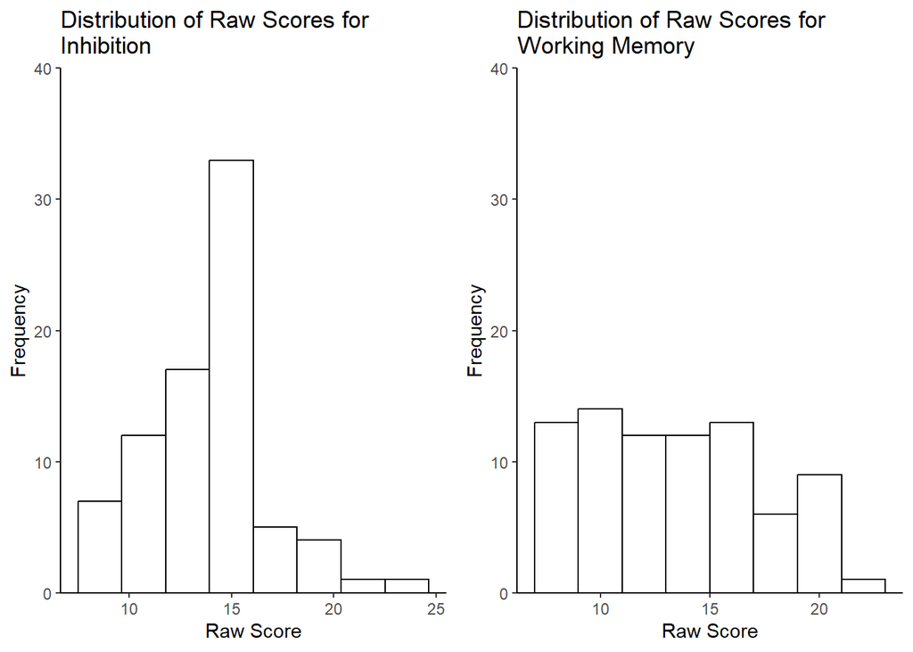

```r
# Calculating the raw score
Inhibition.cleaned <- Inhibition.cleaned %>%
  mutate(Raw.Score = Q1 + Q2 + Q3 + Q4 + Q5 + Q6 + Q7 + Q8)

Working.Memory.cleaned <- Working.Memory.cleaned %>%
  mutate(Raw.Score = Q9 + Q10 + Q11 + Q12 + Q13 + Q14 + Q15 + Q16)

# View the distribution of raw scores
plot1 <- Inhibition.cleaned %>%
  ggplot(aes(x = Raw.Score)) +
  geom_histogram(fill = "white",
                 color = "black",
                 bins = 8) +
  scale_y_continuous(expand = c(0,0), limits = c(0,40)) +
  theme_classic() +
  labs(title = "Distribution of Raw Scores for\nInhibition",
       x = "Raw Score",
       y = "Frequency")


plot2 <- Working.Memory.cleaned %>%
  ggplot(aes(x = Raw.Score)) +
  geom_histogram(fill = "white",
                 color = "black",
                 bins = 8) +
  scale_y_continuous(expand = c(0,0), limits = c(0,40)) +
  theme_classic() +
  labs(title = "Distribution of Raw Scores for\nWorking Memory",
       x = "Raw Score",
       y = "Frequency")


# Print the graphs
ggarrange(plot1, plot2)
```

### Including Age into our IDs

T-scores are a transformation of the raw score that control for the subject’s age. We will need to import each subject’s age and then use that measure to accurately calculate their T-score from their raw score.

```r
# Import demographic information
setwd("~/ONR/Demographics")

# load in demographics
demographics <- read.csv("complete.demographics.csv")

# Extract the age
demo <- demographics %>%
  select(ID, Age)

# Participants with demographic information
msg1 <- paste(length(intersect(Inhibition.cleaned$ID, demo$ID)), "out of our", length(unique(Inhibition.cleaned$ID)), "participants with inhibition data have demographic data", sep =" ")

msg2 <- paste("We need to find the demographic data for the remaining",length(setdiff(Inhibition.cleaned$ID, demo$ID)) ,"participants", sep =" ")

msg3 <- paste(length(intersect(Working.Memory.cleaned$ID, demo$ID)), "out of our", length(unique(Working.Memory.cleaned$ID)), "participants with working memory data have demographic data", sep =" ")

msg4 <- paste("We need to find the demographic data for the remaining",length(setdiff(Working.Memory.cleaned$ID, demo$ID)) ,"participants", sep =" ")

# Print out all of the messages
msg1
```

```
[1] "79 out of our 79 participants with inhibition data have demographic data"
```

```r
msg2
```

```
[1] "We need to find the demographic data for the remaining 0 participants"
```

```r
msg3
```

```
[1] "79 out of our 79 participants with working memory data have demographic data"
```

```r
msg4
```

```
[1] "We need to find the demographic data for the remaining 0 participants"
```

```r
# Merge to include age
Inhibition.cleaned.age <- Inhibition.cleaned %>%
  merge(demo, by = "ID") %>%
  select(ID, Age, Raw.Score, everything())

Working.Memory.cleaned.age <- Working.Memory.cleaned%>%
  merge(demo, by = "ID") %>%
  select(ID, Age, Raw.Score, everything())

# Drop ID's that are missing Age data
Inhibition.cleaned.age <- Inhibition.cleaned.age %>%
  drop_na(Age)

Working.Memory.cleaned.age <- Working.Memory.cleaned.age %>%
  drop_na(Age)
```

### Scoring Inhibition and Working Memory Items [T-Score]

```r
# Calculating T-scores
# Set working directory
setwd("~/ONR/Qualtrics")

# Load in the T-score conversion
T.score.table.18_29 <- read_excel("BRIEF T score conversion table.xlsx", sheet = "18-29")
T.score.table.30_39 <- read_excel("BRIEF T score conversion table.xlsx", sheet = "30-39")

# Data cleaning- drop all rows with NA's
T.score.table.18_29 <- drop_na(T.score.table.18_29)
T.score.table.30_39 <- drop_na(T.score.table.30_39)

# Calculate T scores for inhibition
Inhibition.T.scores <- list()

for(ii in 1:nrow(Inhibition.cleaned.age)) {

  # Set an if statement with the age to determine how to transform the raw score
  if (Inhibition.cleaned.age$Age[ii] < 30) {

    # Extract the current age of the loop
    current.age <- Inhibition.cleaned.age$Age[ii]

    # Extract the current Raw Score
    current.Raw.score <- Inhibition.cleaned.age$Raw.Score[ii]

    # Obtain the T score from the age
    Inhibition.T.scores[[ii]] <- T.score.table.18_29 %>%
      filter(raw.score == current.Raw.score) %>%
      select(inhibit.T) %>%
      unlist()

  } else {

    # Extract the current age of the loop
    current.age <- Inhibition.cleaned.age$Age[ii]

    # Extract the current Raw Score
    current.Raw.score <- Inhibition.cleaned.age$Raw.Score[ii]

    # Obtain the T score from the age
    Inhibition.T.scores[[ii]] <- T.score.table.18_29 %>%
      filter(raw.score == current.Raw.score) %>%
      select(inhibit.T) %>%
      unlist()

  }

}

# Introduce the Inhibit T scores back into the dataframe
Inhibition.cleaned.age$T.score <- unlist(Inhibition.T.scores)

# Calculate T scores for working memory
Working.Memory.T.scores  <- list()

for(ii in 1:nrow(Working.Memory.cleaned.age)) {

  # Set an if statement with the age to determine how to transform the raw score
  if (Working.Memory.cleaned.age$Age[ii] < 30) {

    # Extract the current age of the loop
    current.age <- Working.Memory.cleaned.age$Age[ii]

    # Extract the current Raw Score
    current.Raw.score <- Working.Memory.cleaned.age$Raw.Score[ii]

    # Obtain the T score from the age
    Working.Memory.T.scores[[ii]] <- T.score.table.18_29 %>%
      filter(raw.score == current.Raw.score) %>%
      select(working.T) %>%
      unlist()

  } else {

    # Extract the current age of the loop
    current.age <- Working.Memory.cleaned.age$Age[ii]

    # Extract the current Raw Score
    current.Raw.score <- Working.Memory.cleaned.age$Raw.Score[ii]

    # Obtain the T score from the age
    Working.Memory.T.scores[[ii]] <- T.score.table.18_29 %>%
      filter(raw.score == current.Raw.score) %>%
      select(working.T) %>%
      unlist()

  }

}

# Introduce the Working Memory T scores back into the dataframe
Working.Memory.cleaned.age$T.score <- unlist(Working.Memory.T.scores)
```

### Total data remaining

```r
# Report the total data that we have
paste("We have",length(unique(Inhibition.cleaned.age$ID)), "participants with T-scores for their BRIEF inhibit items")
```

```
[1] "We have 79 participants with T-scores for their BRIEF inhibit items"
```

```r
paste("We have",length(unique(Working.Memory.cleaned.age$ID)), "participants with T-scores for their BRIEF Working Memory items")
```

```
[1] "We have 79 participants with T-scores for their BRIEF Working Memory items"
```

### Save the data

```r
# Set the save directory
setwd("~/ONR/BRIEF")

# Save the data
write.csv(x = Inhibition.cleaned.age,
          file = "Inhibition.T.scores.csv")

write.csv(x = Working.Memory.cleaned.age,
          file = "Working.Memory.T.scores.csv")
```